# Informe

### Distribuciones discretas

#### Variable `Edad`

1. Distribución a utilizar: **Binomial**
2. Construir la variable aleatoria
- X: número de pacientes con edad mayor o igual a 65 años con cáncer de mama en el conjunto de la muestra de tamaño 317
3. Definición de parámetros

$$X \sim Bin(n, p)$$
- Éxito: seleccionar a una paciente con edad mayor o igual a 65 años

p: probabilidad de éxito

```
## [1] 0.3028391
```

n: tamaño de la muestra

```
## [1] 317
```

$$X∼Bin(317,0.3028391)$$
4. Gráfica de densidad

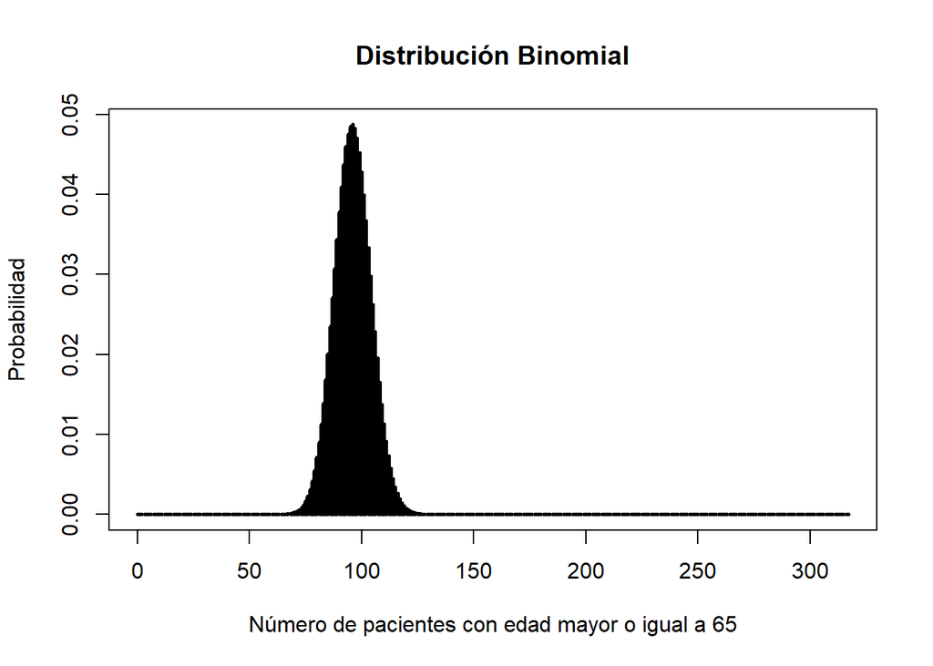

5. Validación de propiedades
- Esperanza

$$\sum_{i = 0}^{n} x_i \cdot
p(x_i)$$

```
## [1] 96
```

$$n \cdot p$$

```
## [1] 96
```

- Varianza

$$\sum_{i = 0}^{n} (x_i-\mu)^2 \cdot
p(x_i)$$

```
## [1] 66.92744
```

$$n \cdot p \cdot q$$
- q: probabilidad de fracaso (1 - p)

```
## [1] 66.92744
```

- Desviación estándar

$$\sqrt{\sum_{i = 0}^{n} (x_i-\mu)^2 \cdot
p(x)}$$

```
## [1] 8.18092
```

$$\sqrt{n \cdot p \cdot q}$$
- q: probabilidad de fracaso (1 - p)

```
## [1] 8.18092
```

6. Ejemplo

Si elegimos a 10 pacientes al azar del estudio de cáncer de mama. ¿Cuál es la probabilidad de que a lo mucho 3 de ellas sean tengan una edad mayor o igual a 65?

```
## [1] 0.6420202
```

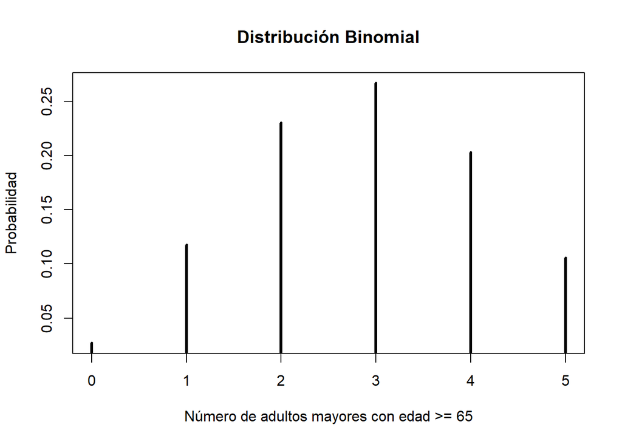

#### Variable `Estado_del_Paciente`

1. Distribución a utilizar: **Hipergeométrica**
- Éxito: seleccionar a un paciente fallecido
2. Variable aleatoria
- X: Cantidad de pacientes fallecidas en una muestra elegida aleatoriamente de 20 pacientes del estudio de cáncer de mama de tamaño 317
3. Definición de parámetros

$$X \sim Hiper(n, m, k)$$

- m: tamaño de la población
- n: número de pacientes fallecidas en la población
- k: tamaño de la muestra

```
## [1] 317
```

```
## [1] 65
```

```
## [1] 20
```

$$X \sim Hiper(317, 65, 20)$$

4. Gráfica de densidad

[figure not shown]

5. Validación de propiedades
- Esperanza

$$\sum_{i = 0}^{n} x_i \cdot
p(x_i)$$

```
## [1] 4.100946
```

$$k \cdot p$$

donde p es la proporción de éxitos

```
## [1] 4.100946
```

- Varianza

$$\sum_{i = 0}^{n} (x_i-\mu)^2 \cdot
p(x_i)$$

```
## [1] 3.064042
```

$$k \cdot p\cdot (1-p) \cdot (\frac{m -
k}{m-1})$$

```
## [1] 3.064042
```

$$\sqrt{\sum_{i = 0}^{n} (x_i-\mu)^2 \cdot
p(x)}$$

```
## [1] 1.750441
```

$$\sqrt{k \cdot p\cdot (1-p) \cdot
(\frac{m - k}{m-1})}$$

```
## [1] 1.750441
```

6. Construcción del ejemplo para validar

Se tienen 317 pacientes de las cuales 252 están vivas. Si se selecciona una muestra de tamaño 20, ¿cuál es la probabilidad de seleccionar 3 pacientes fallecidas si se sabe que no hay reposición?

```
## [1] 0.2014199
```

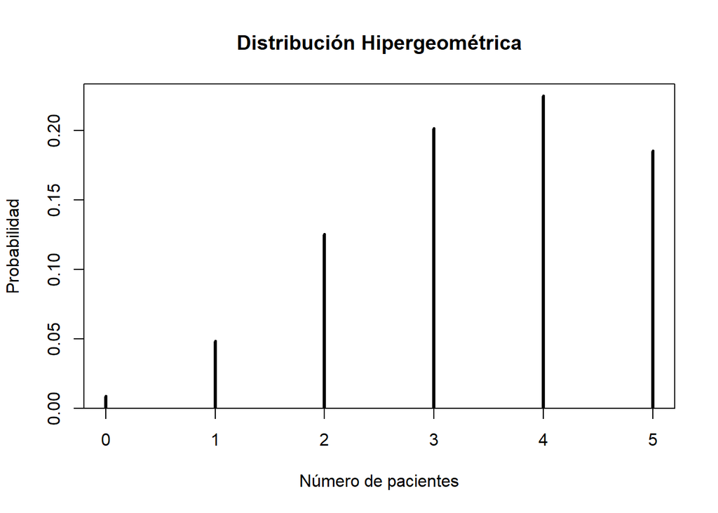

### Distribuciones continuas

#### `Proteína 2` en la etapa I en pacientes vivas

1. Análisis gráfico

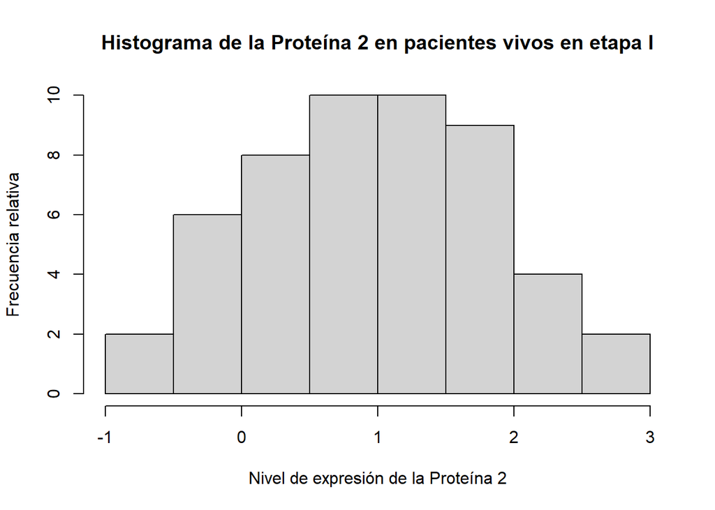

Se observa una forma similar a una campana y que es unimodal, por lo que podría ajustarse a una distribución normal.

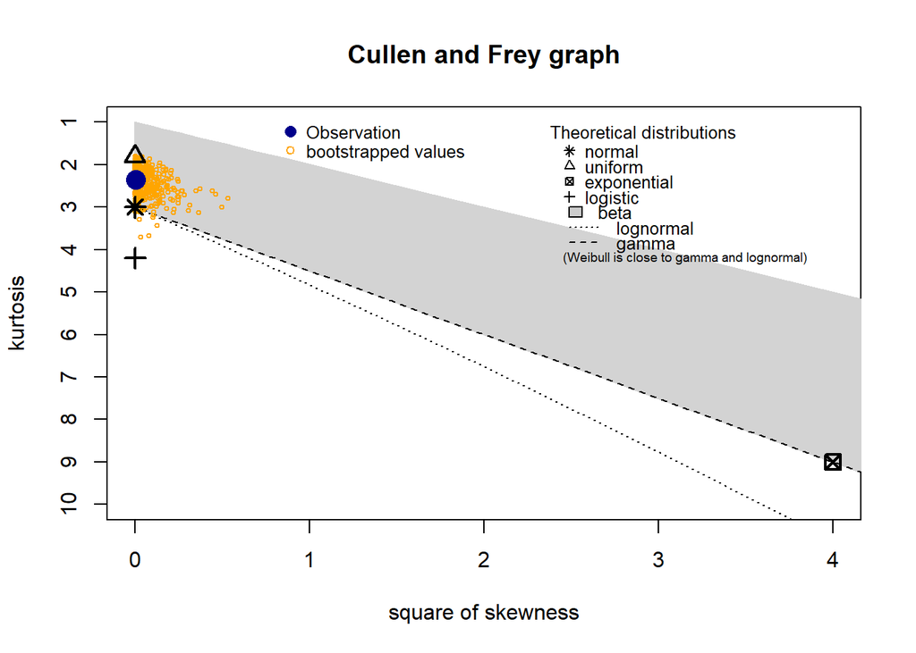

```
## summary statistics
## ------
## min:  -0.94513   max:  2.7513
## median:  0.99713
## mean:  0.9769698
## estimated sd:  0.9027328
## estimated skewness:  -0.05098
## estimated kurtosis:  2.361819
```

Se observa que la distribución tiende a una normal

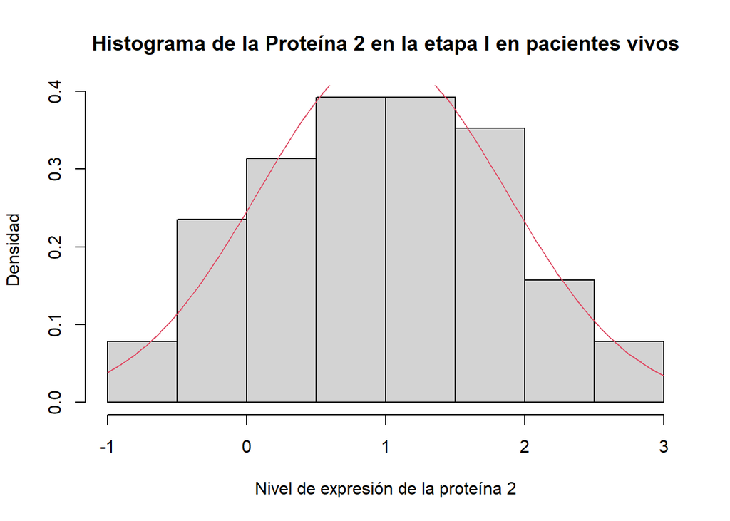

Observación de la gráfica con los parámetros propuestos

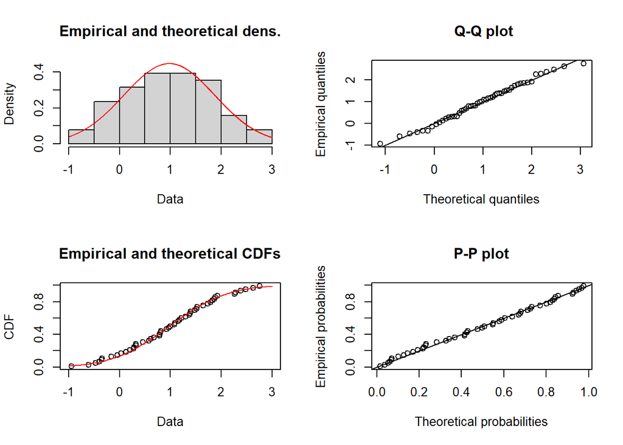

```r
plot(fit)
```

Se observa con más detalle cómo se comportan los datos con el ajuste

Los parámtros obtenidos son los siguientes

```
##      mean        sd
## 0.9769698 0.8938387
```

2. Verificamos las propiedades con los parámetros propuestos
- Media es aproximadamente igual a la mediana

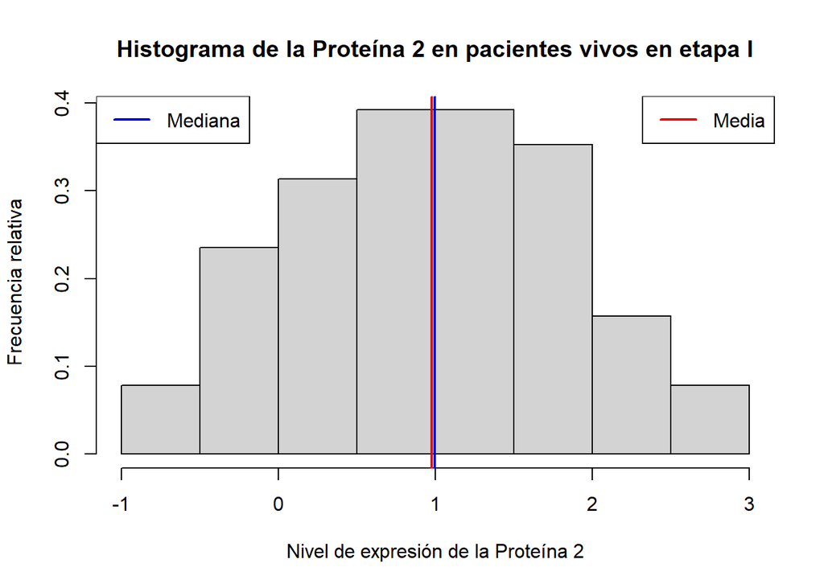

```
## [1] "Media: 0.976969843137255"
```

```
## [1] "Mediana 0.99713"
```

La media y la mediana son cercanas entre sí, por lo que se consideramos que se cumple este criterio.

- Esperanza = media

$$E[g(X)] =
\int_{-\infty}^{+\infty}g(x)f(x)dx$$

Donde $f(x)$ es la función de densidad de probabilidad y $g(x)$ es $x$.

Comparamos el valor esperado obtenido con la media

```r
expected
```

```
## [1] 0.9769698
```

```r
mean(data)
```

```
## [1] 0.9769698
```

Se podría decir que se cumple el criterio de la esperanza dado que lso resultados son aproximadamente iguales

- Varianza = sd<sup>2</sup>

$$Var[X] = E[(x - \mu)^2]$$

Comparamos la varianza esperada con la el valor observado de la varianza:

```r
expected_var
```

```
## [1] 0.7989476
```

```r
sd(data)^2
```

```
## [1] 0.8149265
```

Se ve que los valores son aproximadamente iguales, por lo que se considera que se cumple este criterio

- Test de normalidad

```
## [1] 0.9212637
```

El p-value es mayor a 0.05, por lo que podemos tomar la hipótesis nula de que sigue una distribución aproximadamente normal.

3. Parámetros

$X$: Nivel de expresión de la proteína 2 en pacientes vivos en etapa I

```
##      mean        sd
## 0.9769698 0.8938387
```

De tal forma que:
$$X \sim N(0.9769698,
0.8938387)$$

4. Ejemplo

Se requiere calcular la probabilidad de que el nivel de expresión de la proteína 2 en pacientes vivas en etapa I, sea menor a 0. Se sabe que sigue una distribución normal con media = 0.9769698 y desviación estándar = 0.8938387.

```
## [1] 0.1371959
```

#### `Proteína 1` en pacientes en etapa II

1. Análisis gráfico

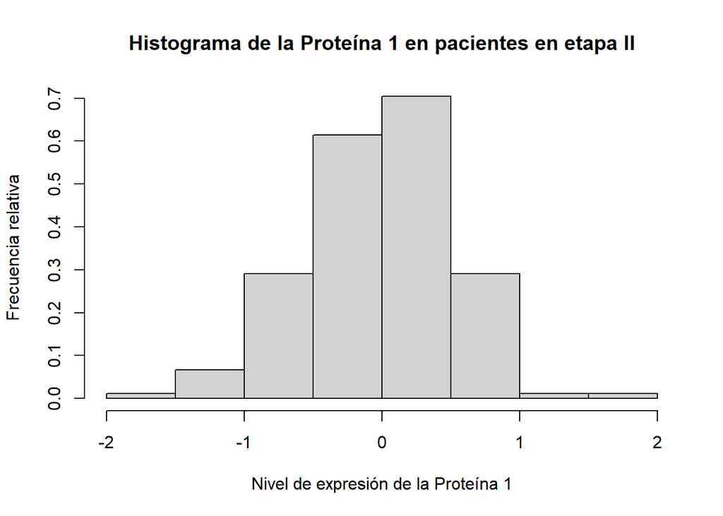

Se observa que parece acampanada y es unimodal, por lo que tal vez podría representarse con una distribución normal.

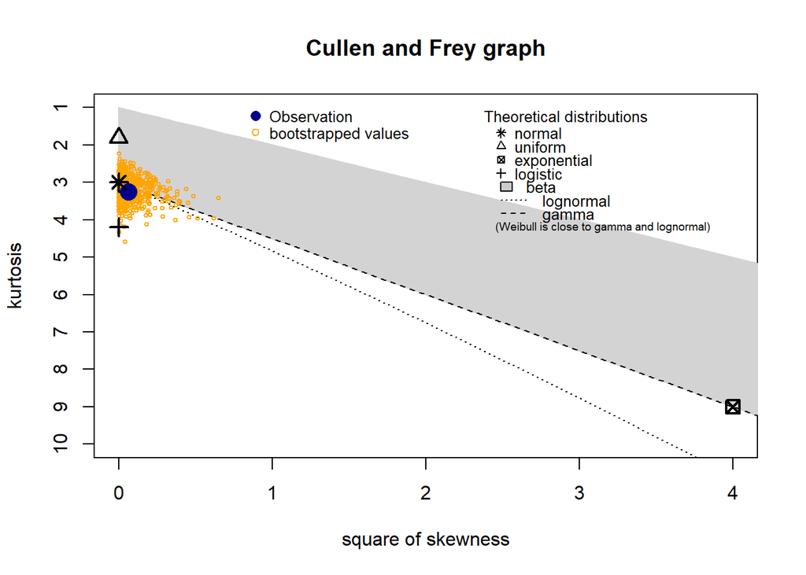

```
## summary statistics
## ------
## min:  -1.6828   max:  1.5936
## median:  0.0056486
## mean:  -0.03308183
## estimated sd:  0.5420538
## estimated skewness:  -0.2512836
## estimated kurtosis:  3.244582
```

El gráfico indica que se acerca a una distribución normal.

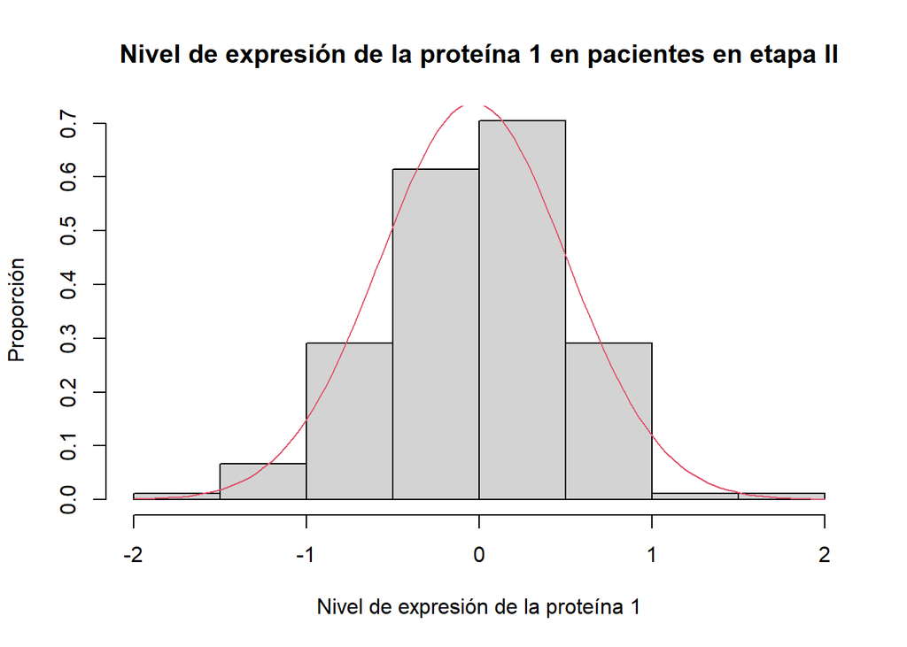

Se observa la distribución normal con los parámetros propuestos en el ajuste.

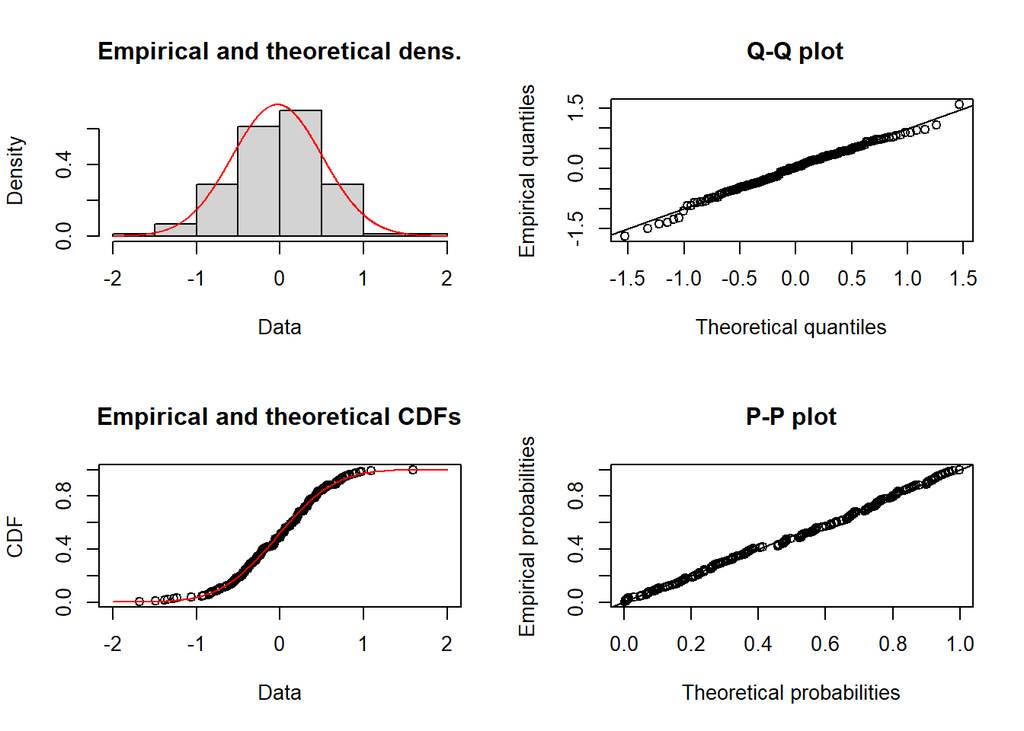

Con más claridad, se observa cómo es que se ajustan los datos a la distribución propuesta.

Los parámetros propuestos son los siguientes

```
##        mean          sd
## -0.03308183  0.54053754
```

2. Verificamos con los parámetros propuestos
- Media es aproximadamente igual a la mediana

[figure not shown]

```
## [1] "Media:  -0.0330818335195531"
```

```
## [1] "Mediana:  0.0056486"
```

Se observa que la media y la mediana son cercanas, pero no aproximadamente iguales.

- Esperanza = media

$$E[g(X)] =
\int_{-\infty}^{+\infty}g(x)f(x)dx$$
Donde $f(x)$ es la función de densidad de probabilidad y $g(x)$ es $x$.

Comparamos el valor esperado obtenido con la media

```r
expected
```

```
## [1] -0.03308183
```

```r
mean(data)
```

```
## [1] -0.03308183
```

Se comprueba que se cumple el criterio de la esperanza

- Varianza = sd<sup>2</sup>

$$Var[X] = E[(x - \mu)^2]$$

Comparamos la varianza esperada con la el valor observado de la varianza:

```r
expected_var
```

```
## [1] 0.2932752
```

```r
sd(data)^2
```

```
## [1] 0.2938223
```

Dado que son aproximadamente iguales, se considera que se cumple este criterio.

- Test de normalidad

```
## [1] 0.5904929
```

Se obtiene un p-value mayor a 0.05, por lo que podríamos aceptar la hipótesis nula de que se distribuye de forma aproximmadamente normal a pesar de que no se cumple que la media es aproximadamente igual a la mediana.

3. Parámetros

```
##        mean          sd
## -0.03308183  0.54053754
```

De tal forma que:

$$X \sim N(-0.03308183,
0.54053754)$$

4. Ejemplo

Se requiere calcular la probabilidad de que el nivel de expresión de la proteína 1 en pacientes en etapa II sea mayor a 0. Se sabe que sigue una distribución normal con media = -0.03308183 y desviación estándar = 0.54053754.

```
## [1] 0.4755993
```

Existe una probabilidad de aproximadamente el 48% de que la paciente tenga un nivel de expresión positivo de la proteína 1.

## Conclusiones

- Se ha determinado que existe una mayor proporción de pacientes vivas en cuanto a fallecidas en la muestra de estudio. Asimismo, se observa una tendencia en cuanto a la edad y el estado del paciente por etapa. Mientras más avanzada sea la etapa, suelen fallecer pacientes más jóvenes. En cuanto a pacientes vivas, a medida que progresa la etapa, el cáncer podría afectar a diversas edades.
- El tipo de cirugía realizada tiene una relación con la etapa del tumor. Se sugiere que, en general, mientras más avanzada sea la etapa, se requiere una cirugía más invasiva que remueva una mayor cantidad de tejidos.
- Las proteínas 1, 2 y 3 no parecen tener un efecto tan significativo en el estado final del paciente, puesto que se observa que en ambos estados tienen tendencias similares. En cuanto a proteína 4, su visibilidad aumenta a medida que progresa la etapa en pacientes fallecidos; mientras que en vivos, es cada vez menor.